# Ecological effects of submarine groundwater discharge and neighborhood interactions on common coral species, Porites rus

## Check model assumptions

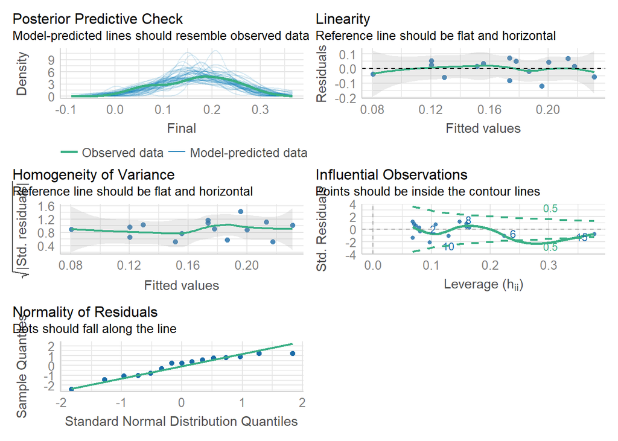

```r
check_model(control_ed_m2)
```

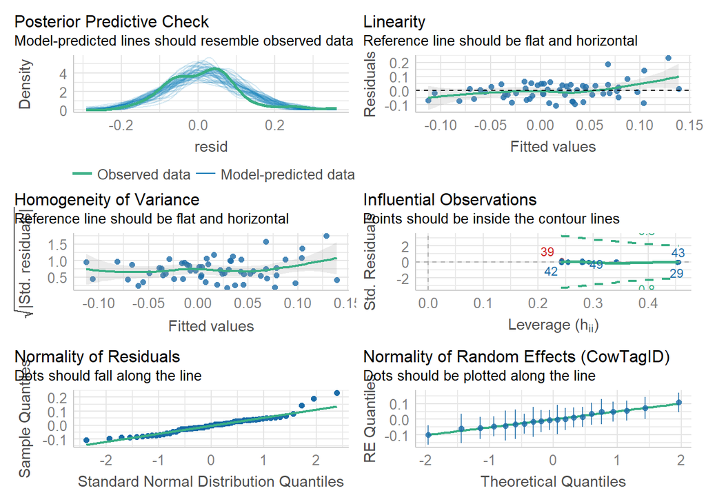

```r
check_model(comp_ed_m)
```

```r
shapiro.test(ED_plot_control$Final)
```

```
##
##  Shapiro-Wilk normality test
##
## data:  ED_plot_control$Final
## W = 0.94644, p-value = 0.4703
```

```r
bartlett.test(Final ~ Treatment, data = ED_plot)
```

```
##
##  Bartlett test of homogeneity of variances
##
## data:  Final by Treatment
## Bartlett's K-squared = 5.9803, df = 3, p-value = 0.1126
```

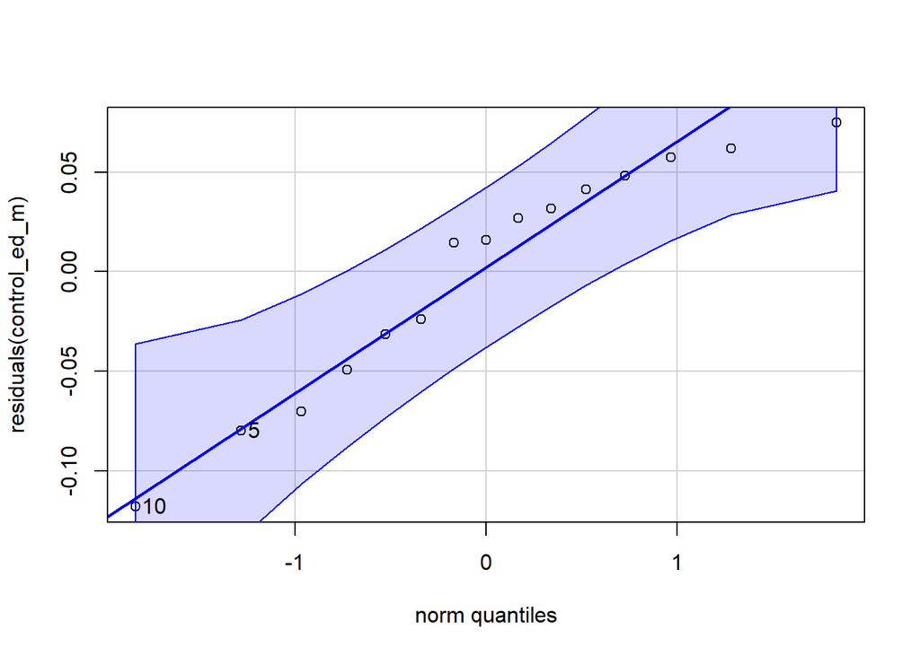

```
## [1] 10  5
```

```r
qqp(residuals(control_ed_m), "norm")
```

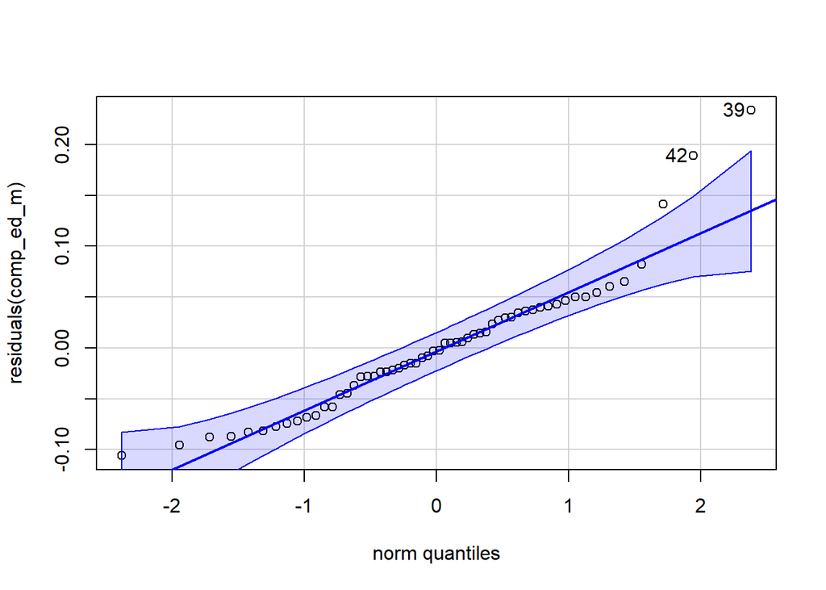

```
## [1] 39 42
```

```r
qqp(residuals(comp_ed_m), "norm")
```

```r
bptest(control_ed_m2)
```

```
##
##  studentized Breusch-Pagan test
##
## data:  control_ed_m2
## BP = 0.84928, df = 1, p-value = 0.3568
```

```r
check_outliers(control_ed_m2)
```

```
## OK: No outliers detected.
```

```r
check_outliers(comp_ed_m) # the 7h fragment
```

[output not shown]

# Chlorophyll content (normalized to SA)

## Model selection for cc

```r
cc_nn_ms <- CC_long_control %>%
ungroup() %>% # ungroup the data
  nest(data = -c(Response_measurement, Predictor_measurement)) %>% # nest all the data measurement type
  mutate(fit = map(data, ~lm(Final~ Predictor_scaled, data = .))) #create models
cc_nn_ms
```

```
## # A tibble: 20 × 4
##    Response_measurement Predictor_measurement data              fit
##    <chr>                <chr>                 <list>            <list>
##  1 CCcm2                min_Temperature_C     <tibble [14 × 9]> <lm>
##  2 CCcm2                max_Temperature_C     <tibble [14 × 9]> <lm>
##  3 CCcm2                mean_Temperature_C    <tibble [14 × 9]> <lm>
##  4 CCcm2                range_Temperature_C   <tibble [14 × 9]> <lm>
##  5 CCcm2                min_NN_umolL          <tibble [14 × 9]> <lm>
##  6 CCcm2                max_NN_umolL          <tibble [14 × 9]> <lm>
##  7 CCcm2                mean_NN_umolL         <tibble [14 × 9]> <lm>
##  8 CCcm2                range_NN_umolL        <tibble [14 × 9]> <lm>
##  9 CCcm2                min_Phosphate_umolL   <tibble [14 × 9]> <lm>
## 10 CCcm2                max_Phosphate_umolL   <tibble [14 × 9]> <lm>
## 11 CCcm2                mean_Phosphate_umolL  <tibble [14 × 9]> <lm>
## 12 CCcm2                range_Phosphate_umolL <tibble [14 × 9]> <lm>
## 13 CCcm2                min_Salinity          <tibble [14 × 9]> <lm>
## 14 CCcm2                max_Salinity          <tibble [14 × 9]> <lm>
## 15 CCcm2                mean_Salinity         <tibble [14 × 9]> <lm>
## 16 CCcm2                range_Salinity        <tibble [14 × 9]> <lm>
## 17 CCcm2                min_pH                <tibble [14 × 9]> <lm>
## 18 CCcm2                max_pH                <tibble [14 × 9]> <lm>
## 19 CCcm2                mean_pH               <tibble [14 × 9]> <lm>
## 20 CCcm2                range_pH              <tibble [14 × 9]> <lm>
```

```r
cc_nn_models <- cc_nn_ms$fit # shows you each of the models

cc_nn_results <- cc_nn_ms %>%
  mutate(coeff = map(fit, tidy),
         aic =  map(fit, glance)) %>% # R2 and others
  select(Predictor_measurement, coeff, aic) %>% # only keep the results
  unnest() %>%
  write_csv(here("Output", "Coefficients", "cc_coefficients.csv"))

cc_nn_results_cleannames <- cc_nn_results %>%
  mutate(Predictor = dplyr::recode(Predictor_measurement,
                            "max_pH" = "Max pH",
                            "max_Salinity" = "Max Salinity",
                            "max_Temperature_C" = "Max Temperature",
                            "max_NN_umolL" = "Max Nitrite + Nitrate",
                            "max_Phosphate_umolL" = "Max Phosphate",
                            "min_pH" = "Min pH",
                            "min_Salinity" = "Min Salinity",
                            "min_Temperature_C" = "Min Temperature",
                            "min_NN_umolL" = "Min Nitrite + Nitrate",
                            "min_Phosphate_umolL" = "Min Phosphate",
                            "range_pH" = "pH Range",
                            "range_Salinity" = "Salinity Range",
                            "range_Temperature_C" = "Temperature Range",
                            "range_Phosphate_umolL" = "Phosphate Range",
                            "range_NN_umolL" = "Nitrate + Nitrate Range",
                            "mean_pH" = "Mean pH",
                            "mean_Salinity" = "Mean Salinity",
                            "mean_Temperature_C" = "Mean Temperature",
                            "mean_NN_umolL" = "Mean Nitrite + Nitrate",
                            "mean_Phosphate_umolL" = "Mean Phosphate")) %>%
  mutate(delAIC = AIC - min(AIC)) %>%
  arrange(delAIC)
```

## Coefficient plot for cc

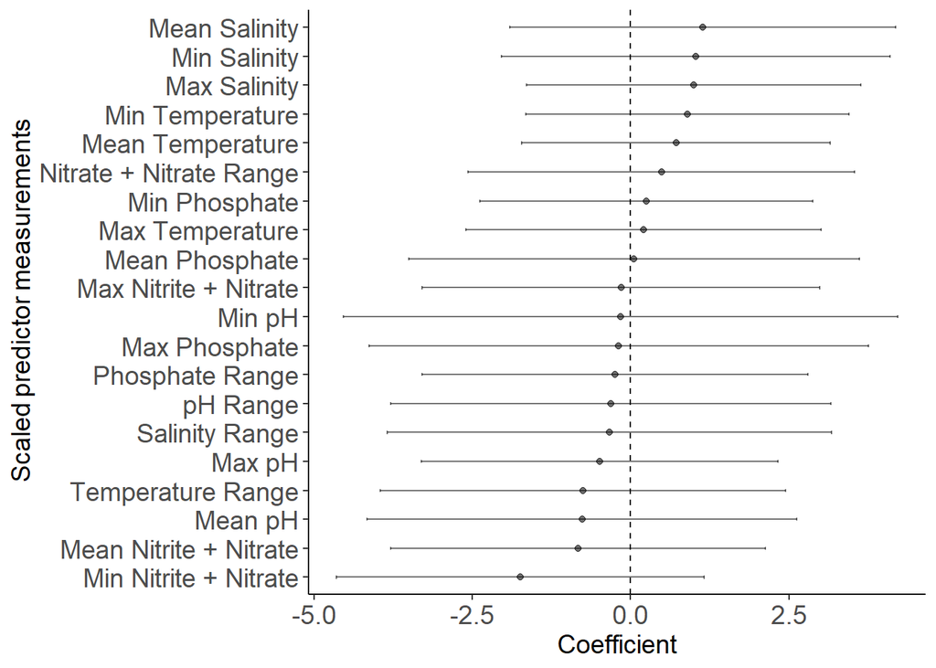

```r
cc_nn_results_cleannames1 <- cc_nn_results_cleannames %>%
  filter(term == "Predictor_scaled") %>%
  mutate(low = estimate - std.error * qnorm(.975), high = estimate + std.error*qnorm(.975)) %>%
  mutate(alpha = case_when(low <= 0 & high >= 0 ~ 0,
                           TRUE ~ 1))

coeff_cc_nn <- ggplot(data = cc_nn_results_cleannames1,
                mapping = aes(x = estimate,
                              y = reorder(Predictor, estimate), alpha = alpha)) +
  theme_classic() +
  geom_vline(xintercept = 0, lty = 2) +
  geom_point() +
  geom_errorbar(mapping = aes(xmax = high, xmin= low), width=0.1) +
  theme(legend.position = "none") +
  labs(y = "Scaled predictor measurements", x = "Coefficient") +
    theme(axis.text = element_text(size = 14),
        legend.text = element_text(size = 12),
        legend.title = element_text(size = 12),
        strip.text = element_text(size = 12),
        axis.title.x = element_markdown(size = 14),
        axis.title.y = element_markdown(size = 14))
coeff_cc_nn
```

## AIC plot for cc

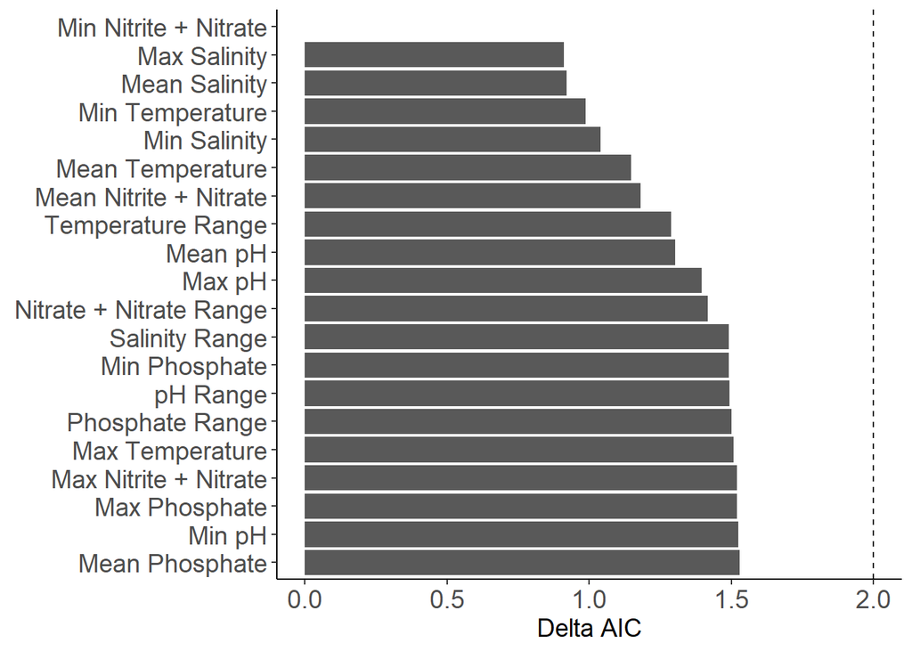

```r
cc_aic_plot_data <- cc_nn_results_cleannames %>%
  select(Predictor, delAIC) %>%
  unique() %>%
  filter(delAIC < 6)

cc_aic_plot <- cc_aic_plot_data %>%
ggplot(mapping = aes(x = reorder(Predictor, -delAIC), y = delAIC)) +
  geom_col() +
  coord_flip() +
  theme_classic() +
  geom_hline(yintercept = 2, lty = 2) +
  labs(x = "", y = "Delta AIC") +
    theme(axis.text = element_text(size = 14),
        legend.text = element_text(size = 12),
        legend.title = element_text(size = 12),
        strip.text = element_text(size = 12),
        axis.title.x = element_markdown(size = 14),
        axis.title.y = element_markdown(size = 14))

cc_aic_plot
```

## Regressions for cc

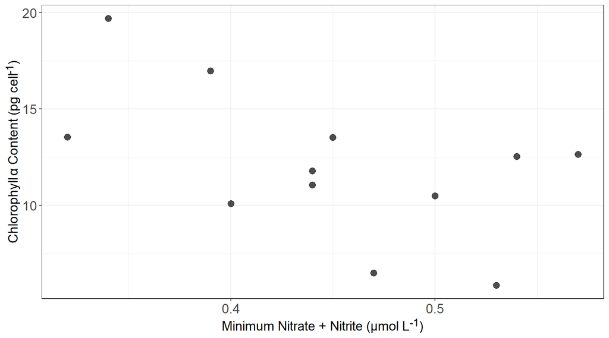

```r
CC_plot1 <- CC_plot
CC_plot1$Treatment <- factor(CC_plot1$Treatment,
                                 levels = c("No_neighbor", "Dead_skeletal", "Conspecific", "Heterospecific"),
                                 labels = c("No Neighbor", "Dead Skeletal", "Conspecific", "Heterospecific"))


cc_plot_control1 <- ggplot(CC_plot_control, mapping = aes(x = min_NN_umolL, y = Final)) +
  geom_point(alpha = 0.7, size = 3, color = "black") +
  theme_bw() +
  scale_color_manual(values = colors) +
  theme(axis.text = element_text(size = 14),
        legend.text = element_text(size = 12),
        legend.title = element_text(size = 12),
        strip.text = element_text(size = 10),
        axis.title.x = element_markdown(size = 14),
        axis.title.y = element_markdown(size = 14)) +
  labs(x = "Minimum Nitrate + Nitrite (µmol L<sup>-1</sup>)", y = "Chlorophyll         α Content (pg cell<sup>-1</sup>)")

cc_plot_control1
```

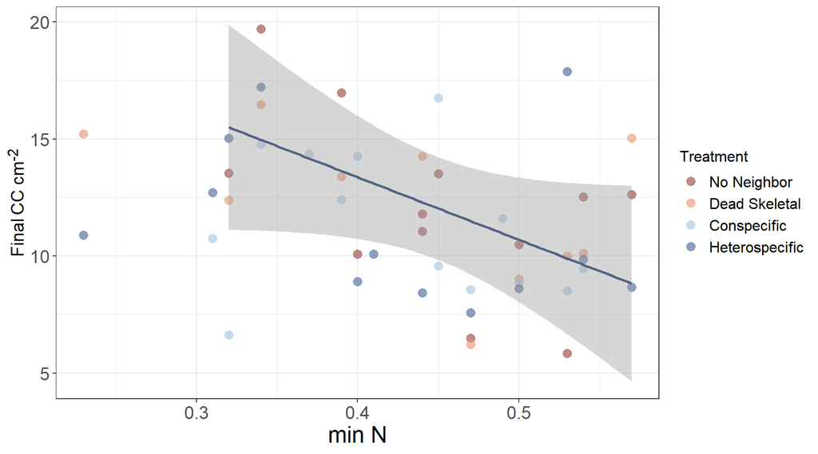

```r
cc_plot_control2 <- ggplot(CC_plot_control, mapping = aes(x = min_NN_umolL, y = Final)) +
  geom_point(CC_plot1, mapping = aes(x = min_NN_umolL, y = Final, color = Treatment), alpha = 0.7, size = 3) +
  geom_smooth(method = "lm", color = "#556385") +
  theme_bw() +
  scale_color_manual(values = colors) +
  theme(axis.text = element_text(size = 14),
        legend.text = element_text(size = 12),
        legend.title = element_text(size = 12),
        strip.text = element_text(size = 10),
        axis.title.x = element_markdown(size = 18),
        axis.title.y = element_markdown(size = 14))+
  labs(x = "min N", y = "Final CC cm<sup>-2</sup>")

cc_plot_control2
```

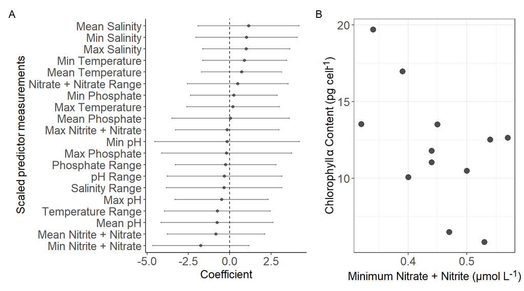

```r
cc_combined <-
  coeff_cc_nn + cc_plot_control1 +
  plot_layout(guides = "collect") +
  plot_annotation(tag_levels = "A")

result_cc <- patchwork::patchworkGrob(cc_combined)
plot_cc <- gridExtra::grid.arrange(result_cc)
```

## Run top model for cc

```r
#create first model for only the no neighbor treatment
control_cc_m <- lm(Final ~ min_NN_umolL, data = CC_plot_control)

summary(control_cc_m)
```

```
##
## Call:
## lm(formula = Final ~ min_NN_umolL, data = CC_plot_control)
##
## Residuals:
##    Min     1Q Median     3Q    Max
## -5.004 -2.295 -0.357  3.008  4.731
##
## Coefficients:
##              Estimate Std. Error t value Pr(>|t|)
## (Intercept)    24.047      6.004   4.005   0.0025 **
## min_NN_umolL  -26.699     13.185  -2.025   0.0704 .
## ---
## Signif. codes:  0 '***' 0.001 '**' 0.01 '*' 0.05 '.' 0.1 ' ' 1
##
## Residual standard error: 3.415 on 10 degrees of freedom
## Multiple R-squared:  0.2908, Adjusted R-squared:  0.2199
## F-statistic:   4.1 on 1 and 10 DF,  p-value: 0.0704
```

```r
glance(control_cc_m)
```

```
## # A tibble: 1 × 12
##   r.squ…¹ adj.r…² sigma stati…³ p.value    df logLik   AIC   BIC devia…⁴ df.re…⁵
##     <dbl>   <dbl> <dbl>   <dbl>   <dbl> <dbl>  <dbl> <dbl> <dbl>   <dbl>   <int>
## 1   0.291   0.220  3.42    4.10  0.0704     1  -30.7  67.3  68.8    117.      10
## # … with 1 more variable: nobs <int>, and abbreviated variable names
## #   ¹r.squared, ²adj.r.squared, ³statistic, ⁴deviance, ⁵df.residual
```

```r
exp_summ_cc <- tidy(control_cc_m) %>% #use tidy to get the slopes and intercept
  select(term, estimate) #select only rows needed here

#save slopes and intercepts

a_cc <- as.numeric(exp_summ_cc %>% filter(term == "min_NN_umolL") %>% select(estimate)) #slope of del15N
# b_cc <- as.numeric(exp_summ_cc %>% filter(term == "Initial") %>% select(estimate))
c_cc <- as.numeric(exp_summ_cc %>% filter(term == "(Intercept)") %>% select(estimate)) #intercept


#calculate expectcc and residuals
CC_plot_pred <- CC_plot %>%
  mutate(predict = (a_cc*min_NN_umolL) + c_cc, #calculate expected value
         resid = Final - predict) %>% #calculate residuals (obs - exp)
  group_by(Treatment) %>% #group by treatment
  mutate(meanresid = mean(resid))

#create residual model to look at differences between treatments
# cowtagID as a random effect. -1 gives us results without intercept
comp_cc_m <- lmer(resid ~ Treatment -1 + (1|CowTagID), data = CC_plot_pred)
summary(comp_cc_m)
```

```
## Linear mixed model fit by REML. t-tests use Satterthwaite's method [
## lmerModLmerTest]
## Formula: resid ~ Treatment - 1 + (1 | CowTagID)
##    Data: CC_plot_pred
##
## REML criterion at convergence: 233.6
##
## Scaled residuals:
##     Min      1Q  Median      3Q     Max
## -1.9807 -0.3855 -0.1598  0.5045  2.9144
##
## Random effects:
##  Groups   Name        Variance Std.Dev.
##  CowTagID (Intercept) 3.513    1.874
##  Residual             8.051    2.838
## Number of obs: 47, groups:  CowTagID, 18
##
## Fixed effects:
##                         Estimate Std. Error       df t value Pr(>|t|)
## TreatmentConspecific    -1.42116    0.92605 40.49176  -1.535    0.133
## TreatmentDead_skeletal  -0.23984    1.04502 42.19113  -0.230    0.820
## TreatmentHeterospecific -1.16360    0.96274 40.85884  -1.209    0.234
## TreatmentNo_neighbor    -0.06659    0.96276 40.89553  -0.069    0.945
##
## Correlation of Fixed Effects:
##             TrtmnC TrtmD_ TrtmnH
## TrtmntDd_sk 0.196
## TrtmntHtrsp 0.205  0.239
## TrtmntN_ngh 0.219  0.237  0.228
```

```r
anova(comp_cc_m)
```

```
## Type III Analysis of Variance Table with Satterthwaite's method
##           Sum Sq Mean Sq NumDF  DenDF F value Pr(>F)
## Treatment 27.667  6.9167     4 25.652  0.8591 0.5015
```

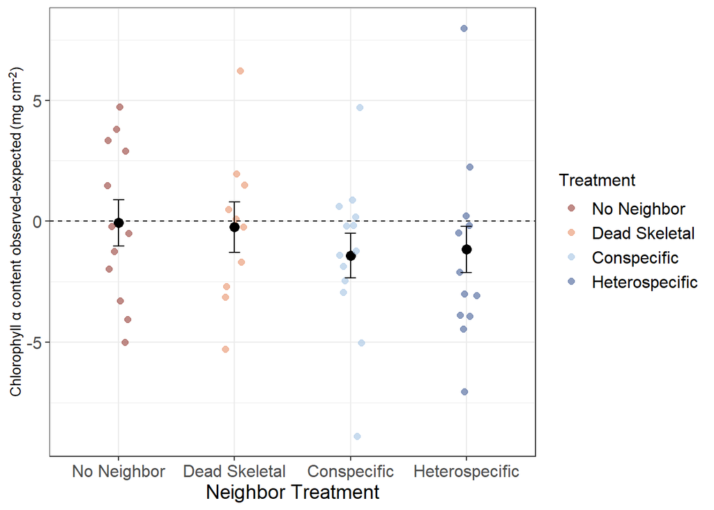

```r
tidy_cc <- tidy(comp_cc_m) %>%
  mutate("Treatment" = term) %>%
  filter(effect == "fixed") %>%
  select(!group) %>%
  mutate(high = estimate + std.error, low = estimate - std.error,
         sig = case_when(p.value <= 0.05 ~ 1,
                         TRUE ~ 0))

tidy_cc$Treatment <- factor(tidy_cc$Treatment, levels = c("TreatmentNo_neighbor", "TreatmentDead_skeletal", "TreatmentConspecific", "TreatmentHeterospecific"),
                           labels = c("No_neighbor", "Dead_skeletal", "Conspecific", "Heterospecific"))

tidy_cc1 <- left_join(CC_plot_pred, tidy_cc)


tidy_cc1$Treatment <- factor(tidy_cc1$Treatment,
                                 levels = c("No_neighbor", "Dead_skeletal", "Conspecific", "Heterospecific"),
                                 labels = c("No Neighbor", "Dead Skeletal", "Conspecific", "Heterospecific"))

label.dfcc <- data.frame(Treatment = c("Conspecific"),
                       estimate = c(0.45))
#make ggplot to show residuals of treatments

cc_plot_resid <- ggplot(tidy_cc1, mapping = aes(x = Treatment, y = estimate)) +
  geom_point(size = 3) +
  geom_jitter(mapping = aes(x = Treatment, y = resid, color = Treatment), size =2,  alpha = 0.7, width = 0.1) +
  geom_errorbar(mapping = aes(ymax = high, ymin= low), width=0.1) +
  labs(y = "Chlorophyll α content observed-expected  (mg cm<sup>-2</sup>)",
                  x = "Neighbor Treatment") +
  theme_bw() +
  scale_color_manual(values = colors) +
  geom_hline(yintercept = 0, lty = 2) +
  theme(axis.text = element_text(size = 12),
        legend.text = element_text(size = 12),
        legend.title = element_text(size = 12),
        strip.text = element_text(size = 12),
        axis.title.x = element_markdown(size = 14),
        axis.title.y = element_markdown(size = 10)) +
  geom_text(data = label.dfr, label = "", size = 10)

cc_plot_resid
```

```r
### now doing with no neighbor as intercept for direct comparison for model stats
CC_plot_pred_table <- CC_plot %>%
  mutate(predict = (a_cc*min_NN_umolL)  + c_cc, #calculate expected value
         resid = Final - predict) %>%
    mutate(across(Treatment, factor, levels = c("No_neighbor", "Dead_skeletal", "Conspecific", "Heterospecific"),
                  labels = c("aNo_neighbor", "Dead_skeletal", "Conspecific", "Heterospecific"))) %>%
  group_by(Treatment) %>% #group by treatment
  mutate(meanresid = mean(resid))

#create residual model to look at differences between treatments
# cowtagID as a random effect. -1 gives us results without intercept
comp_cc_m_table <- lmer(resid ~ Treatment + (1|CowTagID), data = CC_plot_pred_table)
summary(comp_cc_m_table)
```

```
## Linear mixed model fit by REML. t-tests use Satterthwaite's method [
## lmerModLmerTest]
## Formula: resid ~ Treatment + (1 | CowTagID)
##    Data: CC_plot_pred_table
##
## REML criterion at convergence: 233.6
##
## Scaled residuals:
##     Min      1Q  Median      3Q     Max
## -1.9807 -0.3855 -0.1598  0.5045  2.9144
##
## Random effects:
##  Groups   Name        Variance Std.Dev.
##  CowTagID (Intercept) 3.513    1.874
##  Residual             8.051    2.838
## Number of obs: 47, groups:  CowTagID, 18
##
## Fixed effects:
##                         Estimate Std. Error       df t value Pr(>|t|)
## (Intercept)             -0.06659    0.96276 40.89553  -0.069    0.945
## TreatmentDead_skeletal  -0.17326    1.24209 30.12745  -0.139    0.890
## TreatmentConspecific    -1.35458    1.18038 32.77344  -1.148    0.259
## TreatmentHeterospecific -1.09702    1.19637 31.62135  -0.917    0.366
##
## Correlation of Fixed Effects:
##             (Intr) TrtmD_ TrtmnC
## TrtmntDd_sk -0.576
## TrtmntCnspc -0.644  0.466
## TrtmntHtrsp -0.621  0.483  0.498
```

```r
anova(comp_cc_m_table)
```

```
## Type III Analysis of Variance Table with Satterthwaite's method
##           Sum Sq Mean Sq NumDF  DenDF F value Pr(>F)
## Treatment 14.883  4.9611     3 31.938  0.6162 0.6096
```

## Check model assumptions

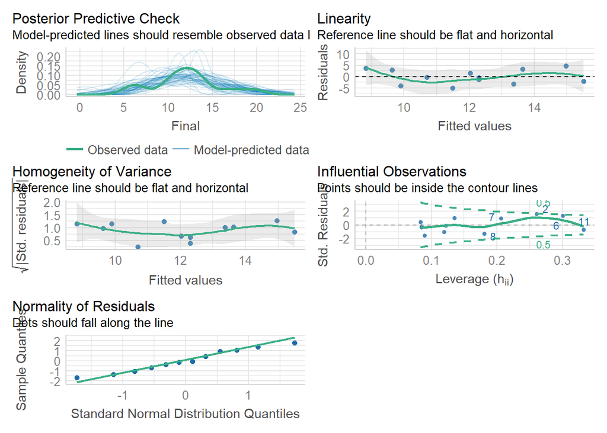

```r
check_model(control_cc_m)
```

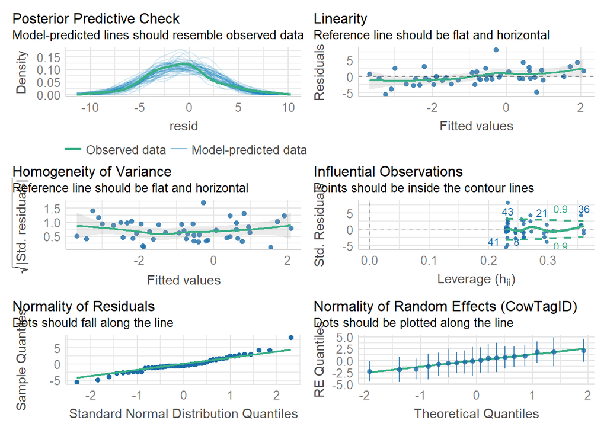

```r
check_model(comp_cc_m)
```

```r
shapiro.test(CC_plot_control$Final)
```

```
##
##  Shapiro-Wilk normality test
##
## data:  CC_plot_control$Final
## W = 0.95489, p-value = 0.7091
```

```r
bartlett.test(Final ~ Treatment, data = CC_plot)
```

```
##
##  Bartlett test of homogeneity of variances
##
## data:  Final by Treatment
## Bartlett's K-squared = 0.70545, df = 3, p-value = 0.8719
```

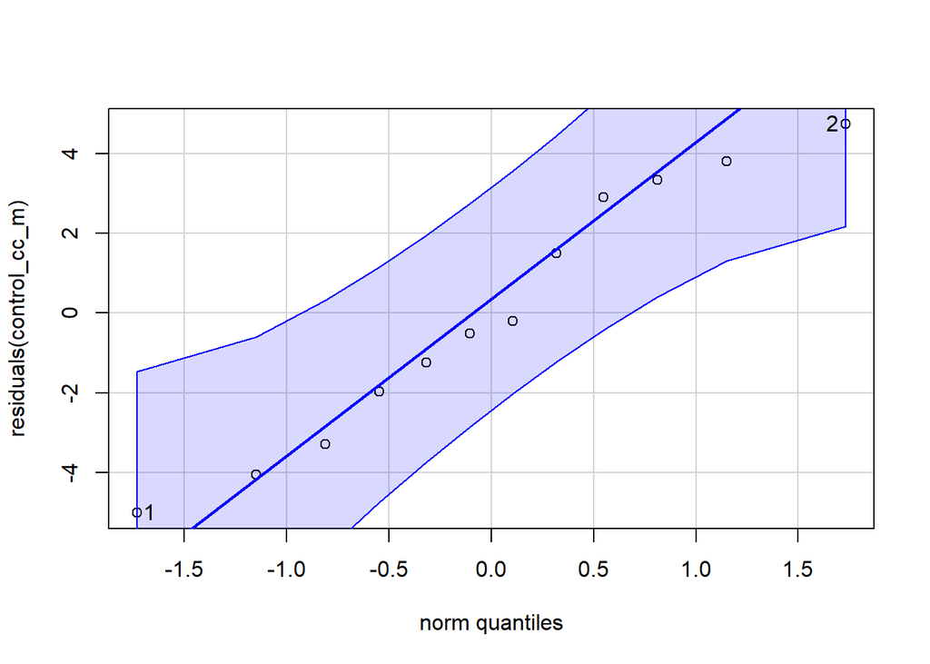

```
## [1] 1 2
```

```r
qqp(residuals(control_cc_m), "norm")
```

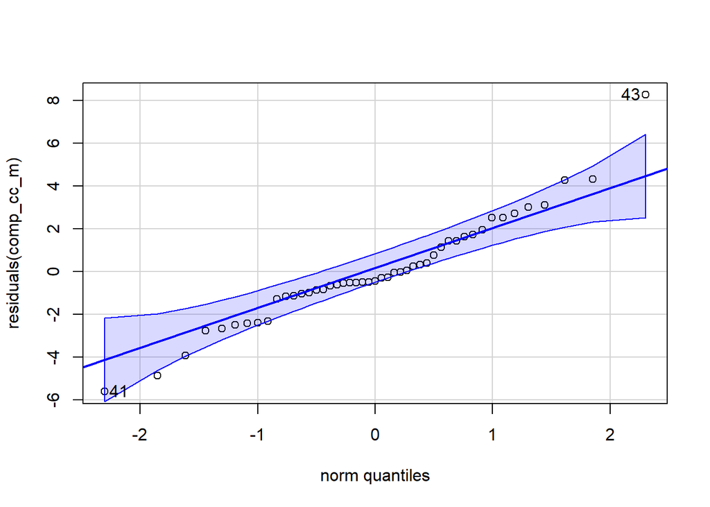

```
## [1] 43 41
```

```r
qqp(residuals(comp_cc_m), "norm")
```

```r
bptest(control_cc_m)
```

```
##
##  studentized Breusch-Pagan test
##
## data:  control_cc_m
## BP = 0.010704, df = 1, p-value = 0.9176
```

## Combined plots

### AIC plots

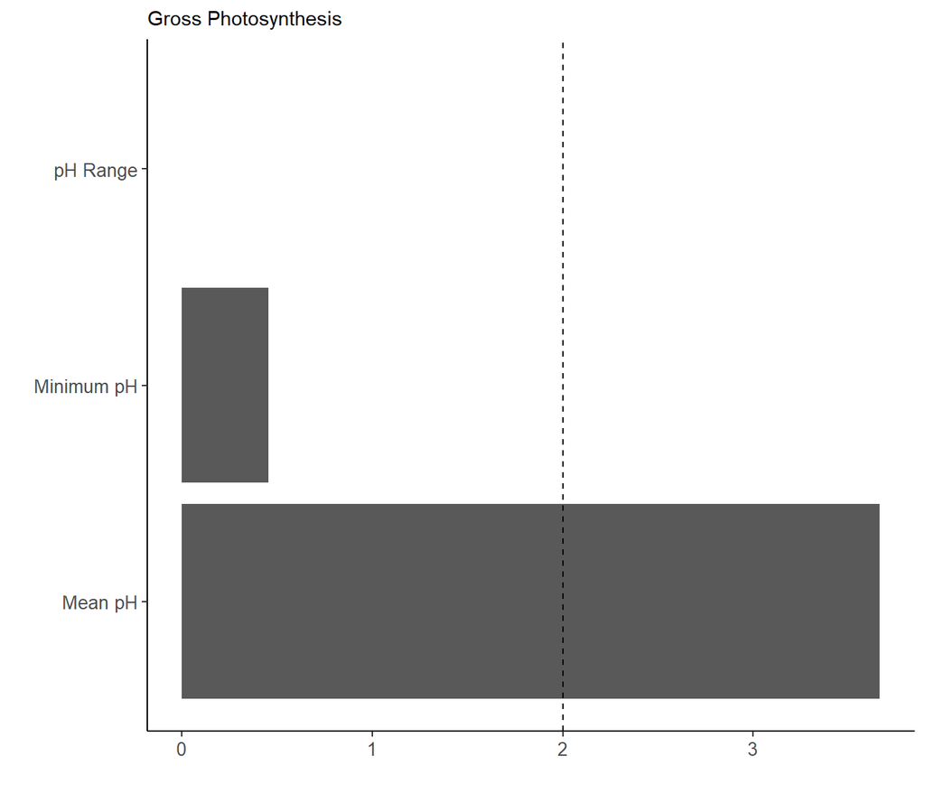

```r
gp_aic_patch <- gp_aic_plot_data %>%
ggplot(mapping = aes(x = reorder(Predictor, -delAIC), y = delAIC)) +
  geom_col() +
  coord_flip() +
  theme_classic() +
  geom_hline(yintercept = 2, lty = 2) +
  labs(x = "", y = "", title = "Gross Photosynthesis") +
  theme(axis.text = element_text(size = 10),
        legend.text = element_text(size = 12),
        legend.title = element_text(size = 12),
        strip.text = element_text(size = 10),
        axis.title = element_markdown(size = 11),
        title = element_text(size = 9)) +
  scale_x_discrete(labels = rev(c("pH Range", "Minimum pH", "Mean pH")))
gp_aic_patch
```

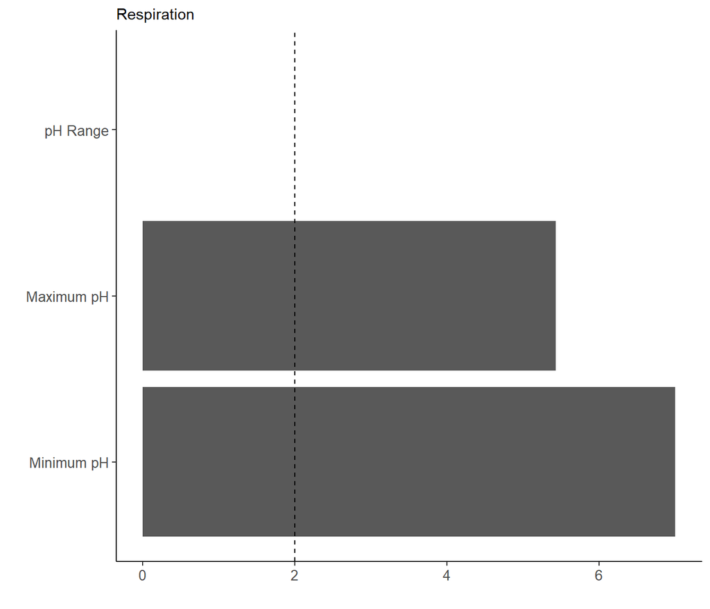

```r
r_aic_patch <- r_aic_plot_data %>%
ggplot(mapping = aes(x = reorder(Predictor, -delAIC), y = delAIC)) +
  geom_col() +
  coord_flip() +
  theme_classic() +
  geom_hline(yintercept = 2, lty = 2) +
  labs(x = "", y = "", title = "Respiration") +
    theme(axis.text = element_text(size = 10),
        legend.text = element_text(size = 12),
        legend.title = element_text(size = 12),
        strip.text = element_text(size = 12),
        axis.title = element_markdown(size = 11),
        title = element_text(size = 9)) +
  scale_x_discrete(labels = rev(c("pH Range", "Maximum pH", "Minimum pH")))
r_aic_patch
```

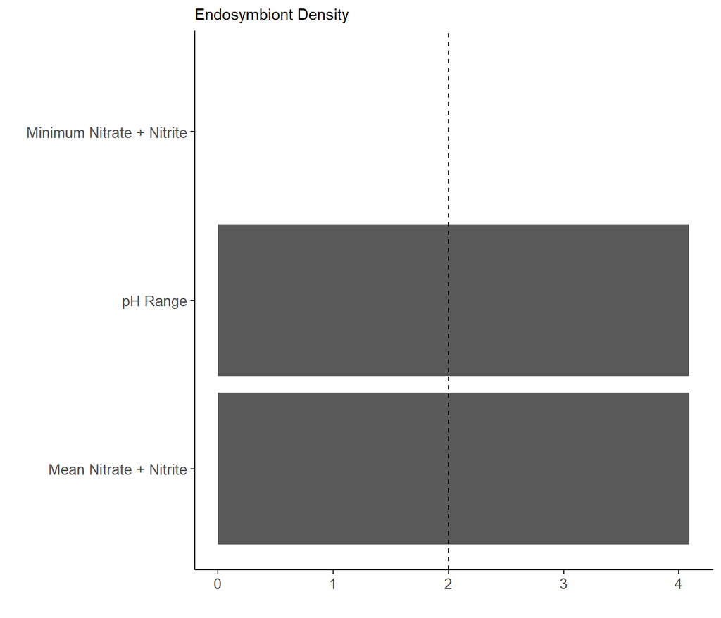

```r
ed_aic_patch <- ed_aic_plot_data %>%
ggplot(mapping = aes(x = reorder(Predictor, -delAIC), y = delAIC)) +
  geom_col() +
  coord_flip() +
  theme_classic() +
  geom_hline(yintercept = 2, lty = 2) +
  labs(x = "", y = "", title = "Endosymbiont Density") +
    theme(axis.text = element_text(size = 10),
        legend.text = element_text(size = 12),
        legend.title = element_text(size = 12),
        strip.text = element_text(size = 12),
        axis.title = element_markdown(size = 11),
        title = element_text(size = 9)) +
  scale_x_discrete(labels = rev(c("Minimum Nitrate + Nitrite", "pH Range", "Mean Nitrate + Nitrite")))
ed_aic_patch
```

[figure not shown]

```r
cc_aic_patch <- cc_aic_plot_data %>%
ggplot(mapping = aes(x = reorder(Predictor, -delAIC), y = delAIC)) +
  geom_col() +
  coord_flip() +
  theme_classic() +
  geom_hline(yintercept = 2, lty = 2) +
  labs(x = "", y = "", title = "Chlorophyll a Content (cell-1)") +
    theme(axis.text = element_text(size = 10),
        legend.text = element_text(size = 12),
        legend.title = element_text(size = 12),
        strip.text = element_text(size = 12),
        axis.title = element_markdown(size = 11),
        title = element_text(size = 9)) +
  scale_x_discrete(labels = rev(c("pH Range", "Temperature Range", "Salinity Range")))


aic_combined <-
  ed_aic_patch + cc_aic_patch + gp_aic_patch + r_aic_patch +
  plot_layout(guides = "collect") +
  plot_annotation(tag_levels = "A")

result_aic <- patchwork::patchworkGrob(aic_combined)
plot_aic <- gridExtra::grid.arrange(result_aic,
                                    bottom = "ΔAIC")
```

### Control plots - only neighbor treatment

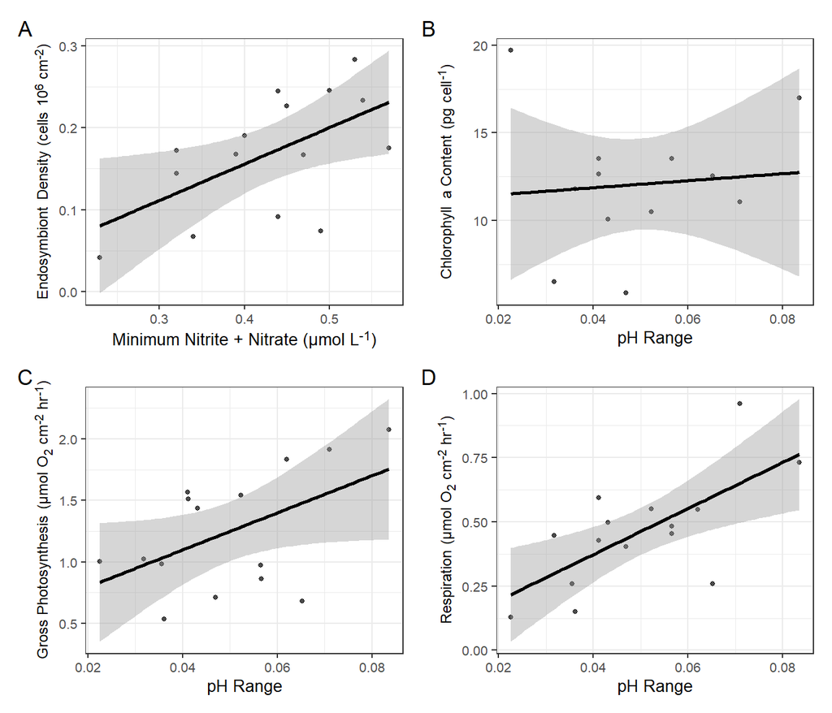

```r
gp_plot_control1 <- ggplot(GP_plot_control, mapping = aes(x = range_pH, y = Final)) +
  geom_point(alpha = 0.7, size = 1) +
  geom_smooth(method = "lm", color = "black") +
  theme_bw() +
  scale_color_manual(values = colors) +
  theme(axis.text = element_text(size = 8),
        legend.text = element_text(size = 12),
        legend.title = element_text(size = 12),
        strip.text = element_text(size = 10),
        axis.title.x = element_markdown(size = 10),
        axis.title.y = element_markdown(size = 9)) +
  labs(x = "pH Range", y = "Gross Photosynthesis (µmol O<sub>2</sub> cm<sup>-2</sup> hr<sup>-1</sup>)")

r_plot_control1 <- ggplot(R_plot_control, mapping = aes(x = range_pH, y = Final)) +
  geom_point(alpha = 0.7, size = 1) +
  geom_smooth(method = "lm", color = "black") +
  theme_bw() +
  scale_color_manual(values = colors) +
  theme(axis.text = element_text(size = 8),
        legend.text = element_text(size = 12),
        legend.title = element_text(size = 12),
        strip.text = element_text(size = 10),
        axis.title.x = element_markdown(size = 10),
        axis.title.y = element_markdown(size = 9)) +
  labs(x = "pH Range", y = "Respiration (µmol O<sub>2</sub> cm<sup>-2</sup> hr<sup>-1</sup>)")

ed_plot_control1 <- ggplot(ED_plot_control, mapping = aes(x = min_NN_umolL, y = Final)) +
  geom_point(alpha = 0.7, size = 1) +
  geom_smooth(method = "lm", color = "black") +
  theme_bw() +
  scale_color_manual(values = colors) +
  theme(axis.text = element_text(size = 8),
        legend.text = element_text(size = 12),
        legend.title = element_text(size = 12),
        strip.text = element_text(size = 10),
        axis.title.x = element_markdown(size = 10),
        axis.title.y = element_markdown(size = 9)) +
  labs(x = "Minimum Nitrite + Nitrate (µmol L<sup>-1</sup>)", y = "Endosymbiont           Density (cells 10<sup>6</sup> cm<sup>-2</sup>)")

cc_plot_control1 <- ggplot(CC_plot_control, mapping = aes(x = range_pH, y = Final)) +
  geom_point(alpha = 0.7, size = 1) +
  geom_smooth(method = "lm", color = "black") +
  theme_bw() +
  scale_color_manual(values = colors) +
  theme(axis.text = element_text(size = 8),
        legend.text = element_text(size = 12),
        legend.title = element_text(size = 12),
        strip.text = element_text(size = 10),
        axis.title.x = element_markdown(size = 10),
        axis.title.y = element_markdown(size = 9)) +
  labs(x = "pH Range", y = "Chlorophyll         a Content (pg cell<sup>-1</sup>)")


control1_combined <-
  ed_plot_control1 + cc_plot_control1 + gp_plot_control1 + r_plot_control1 +
  plot_layout(guides = "collect", heights = 20) +
  plot_annotation(tag_levels = "A")

result_control1 <- patchwork::patchworkGrob(control1_combined)
plot_control1 <- gridExtra::grid.arrange(result_control1)
```

### Control plots- all observations overlaid (supplemental material)

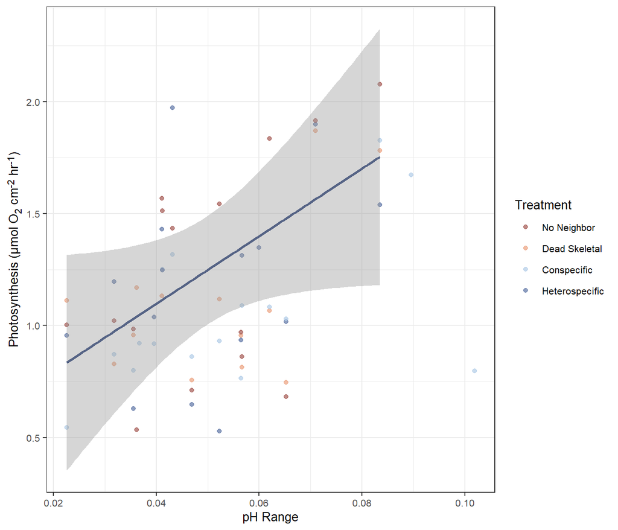

```r
gp_plot_control2 <- ggplot(GP_plot_control, mapping = aes(x = range_pH, y = Final)) +
  geom_point(GP_plot1, mapping = aes(x = range_pH, y = Final, color = Treatment), alpha = 0.7, size = 1.5) +
  geom_smooth(method = "lm", color = "#556385") +
  theme_bw() +
  scale_color_manual(values = colors) +
  theme(axis.text = element_text(size = 8),
        legend.text = element_text(size = 8),
        legend.title = element_text(size = 10),
        strip.text = element_text(size = 10),
        axis.title.x = element_markdown(size = 10),
        axis.title.y = element_markdown(size = 10)) +
  labs(x = "pH Range", y = "Photosynthesis (µmol O<sub>2</sub> cm<sup>-2</sup> hr<sup>-1</sup>)")

gp_plot_control2
```

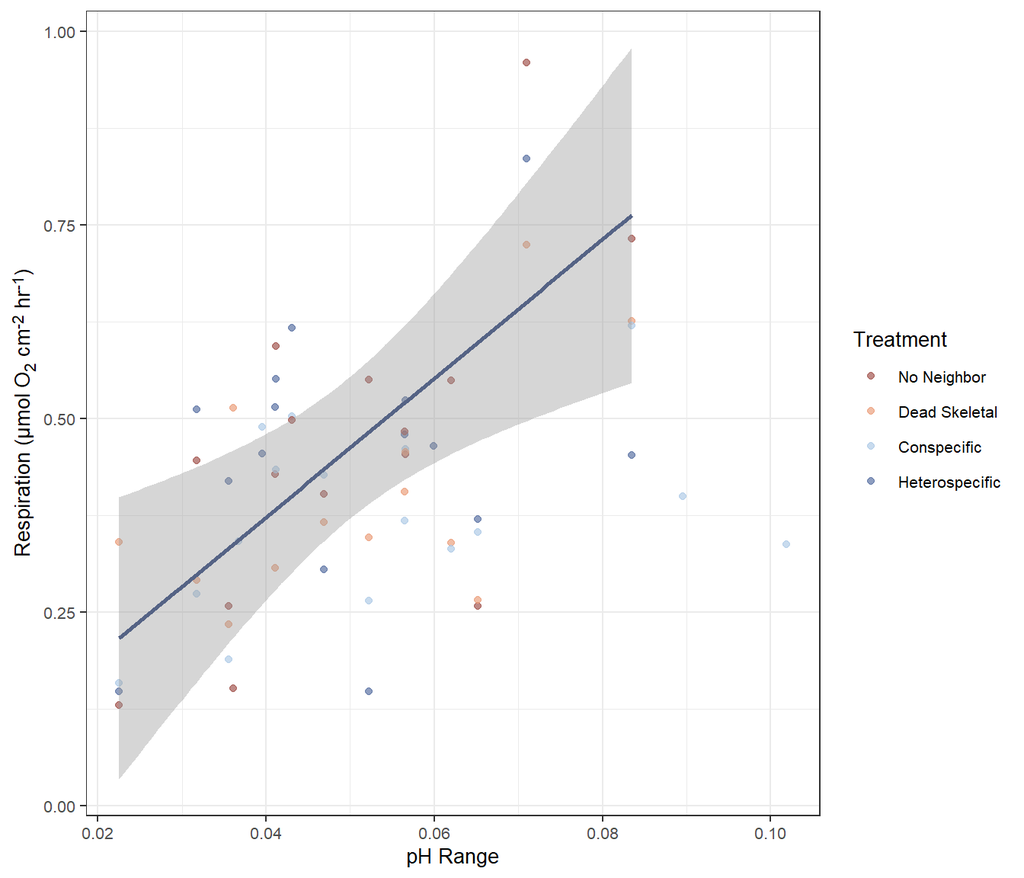

```r
r_plot_control2 <- ggplot(R_plot_control, mapping = aes(x = range_pH, y = Final)) +
  geom_point(R_plot1, mapping = aes(x = range_pH, y = Final, color = Treatment), alpha = 0.7, size = 1.5) +
  geom_smooth(method = "lm", color = "#556385") +
  theme_bw() +
  scale_color_manual(values = colors) +
  theme(axis.text = element_text(size = 8),
        legend.text = element_text(size = 8),
        legend.title = element_text(size = 10),
        strip.text = element_text(size = 10),
        axis.title.x = element_markdown(size = 10),
        axis.title.y = element_markdown(size = 10)) +
  labs(x = "pH Range", y = "Respiration (µmol O<sub>2</sub> cm<sup>-2</sup> hr<sup>-1</sup>)")

r_plot_control2
```

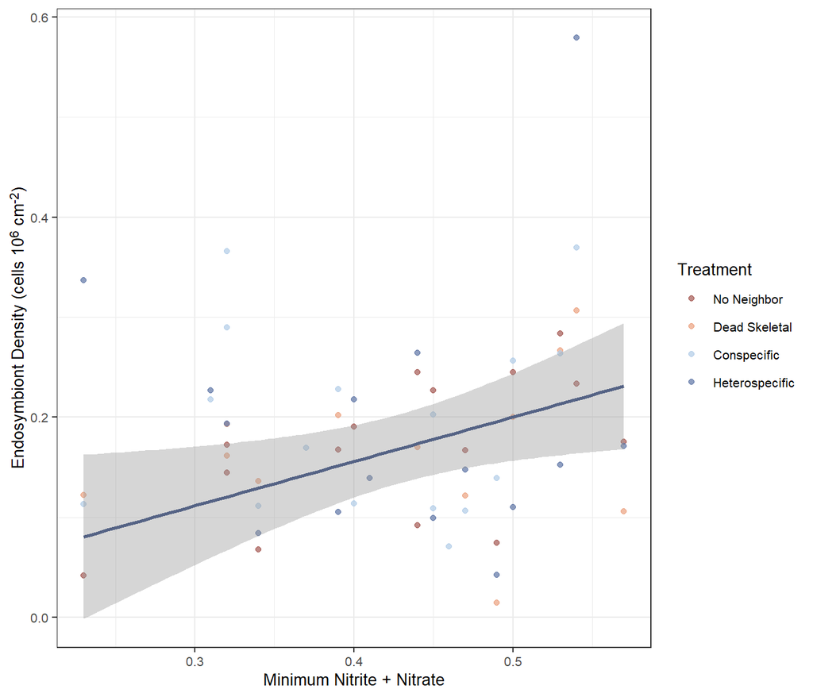

```r
ed_plot_control2 <- ggplot(ED_plot_control, mapping = aes(x = min_NN_umolL, y = Final)) +
  geom_point(ED_plot1, mapping = aes(x = min_NN_umolL, y = Final, color = Treatment), alpha = 0.7, size = 1.5) +
  geom_smooth(method = "lm", color = "#556385") +
  theme_bw() +
  scale_color_manual(values = colors) +
  theme(axis.text = element_text(size = 8),
        legend.text = element_text(size = 8),
        legend.title = element_text(size = 10),
        strip.text = element_text(size = 10),
        axis.title.x = element_markdown(size = 10),
        axis.title.y = element_markdown(size = 10)) +
  labs(x = "Minimum Nitrite + Nitrate", y = "Endosymbiont Density (cells 10<sup>6</sup> cm<sup>-2</sup>)")

ed_plot_control2
```

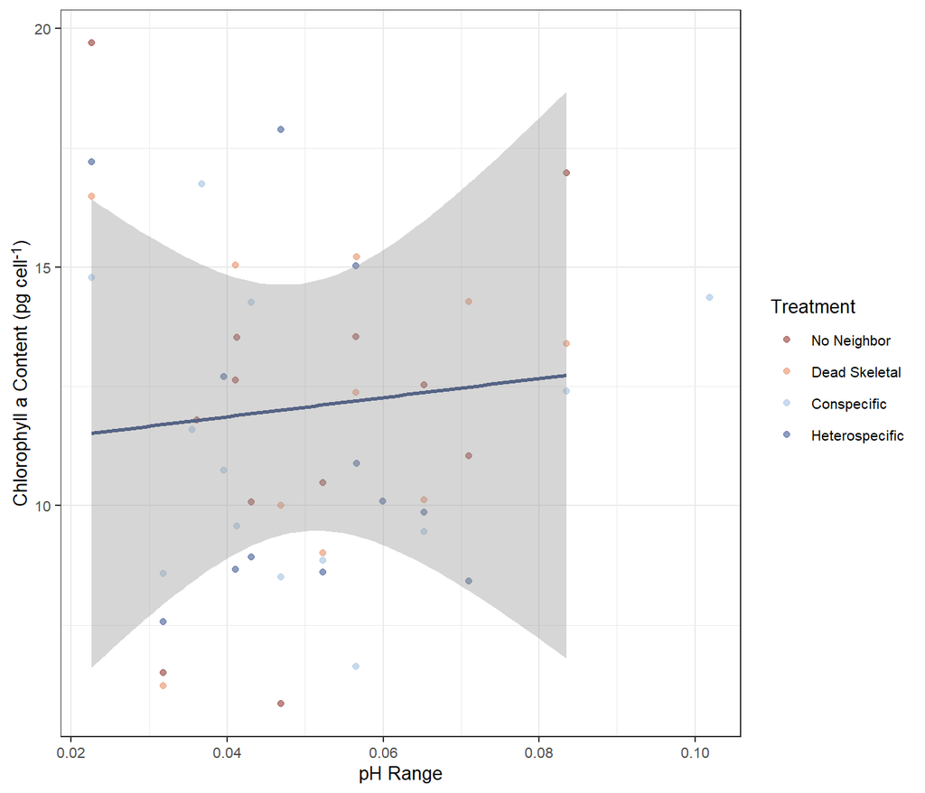

```r
cc_plot_control2 <- ggplot(CC_plot_control, mapping = aes(x = range_pH, y = Final)) +
  geom_point(CC_plot1, mapping = aes(x = range_pH, y = Final, color = Treatment), alpha = 0.7, size = 1.5) +
  geom_smooth(method = "lm", color = "#556385") +
  theme_bw() +
  scale_color_manual(values = colors) +
  theme(axis.text = element_text(size = 8),
        legend.text = element_text(size = 8),
        legend.title = element_text(size = 10),
        strip.text = element_text(size = 10),
        axis.title.x = element_markdown(size = 10),
        axis.title.y = element_markdown(size = 10)) +
  labs(x = "pH Range", y = "Chlorophyll a Content (pg cell<sup>-1</sup>)")

cc_plot_control2
```

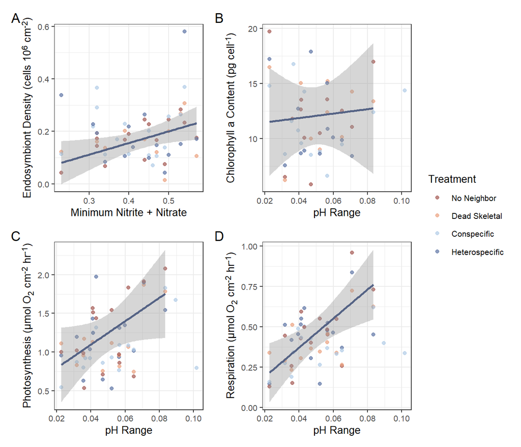

```r
control2_combined <-
  ed_plot_control2 + cc_plot_control2 + gp_plot_control2 + r_plot_control2 +
  plot_layout(guides = "collect") +
  plot_annotation(tag_levels = "A")

result_control2 <- patchwork::patchworkGrob(control2_combined)
plot_control2 <- gridExtra::grid.arrange(result_control2)
```

```r
plot_control2
```

### Treatment residual plots combined

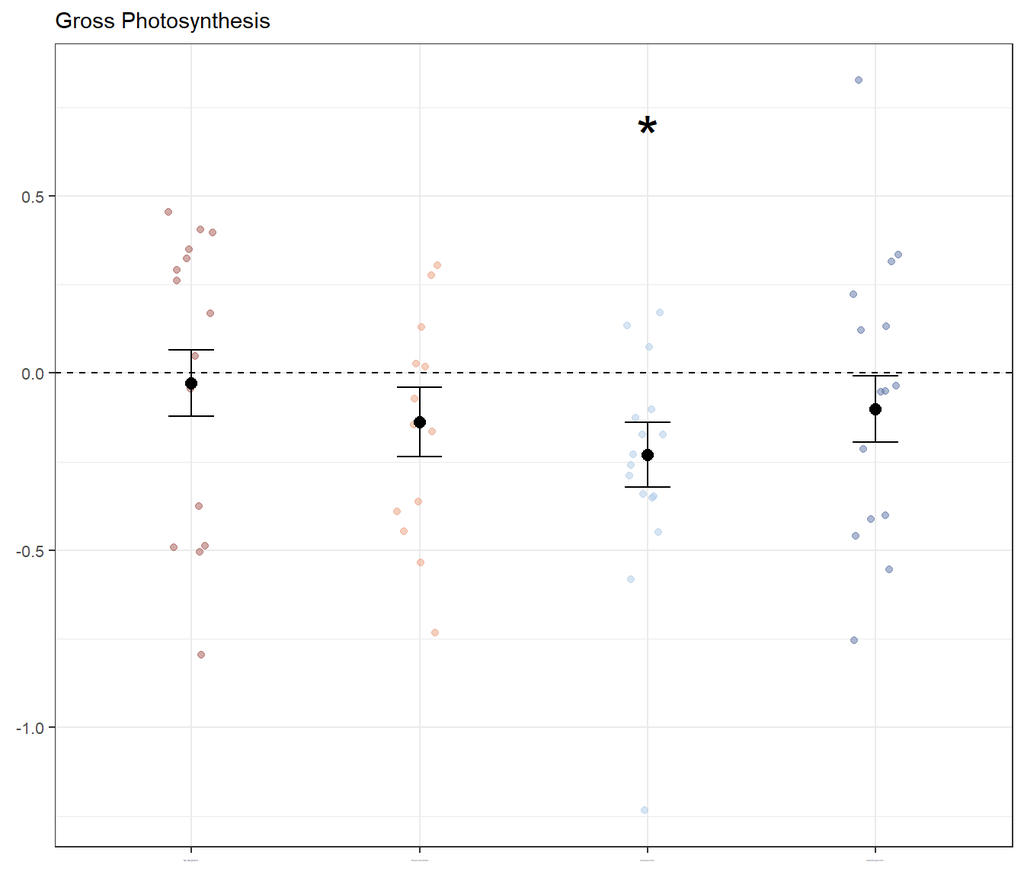

```r
gp_plot_resid <- ggplot(tidy_gp1, mapping = aes(x = Treatment, y = estimate)) +
    geom_jitter(mapping = aes(x = Treatment, y = resid, color = Treatment), size =1.5,  alpha = 0.5, width = 0.1) +
      geom_point(size = 2.5) +
  geom_errorbar(mapping = aes(ymax = high, ymin= low), width=0.2) +
  labs(y = "", x = "", title = "Gross Photosynthesis") +
  theme_bw() +
  scale_color_manual(values = colors) +
  geom_hline(yintercept = 0, lty = 2) +
  theme(axis.text.y = element_text(size = 8),
        axis.text.x = element_text(size = 1),
        legend.position = "none",
        strip.text = element_text(size = 10),
        axis.title.x = element_markdown(size = 10),
        axis.title.y = element_markdown(size = 10),
        title = element_text(size = 9)) +
  geom_text(data = label.df, label = "*", size = 10, y = 0.67)

gp_plot_resid
```

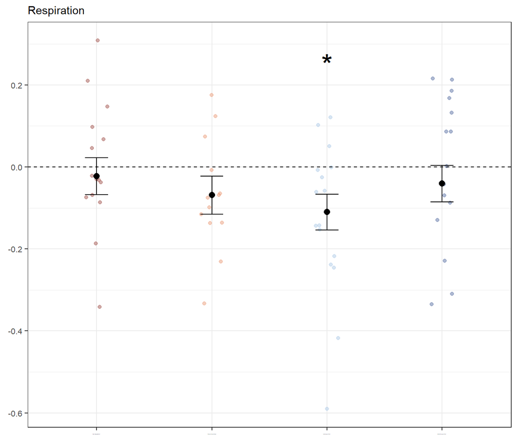

```r
r_plot_resid <- ggplot(tidy_r1, mapping = aes(x = Treatment, y = estimate)) +
  geom_jitter(mapping = aes(x = Treatment, y = resid, color = Treatment), size =1.5,  alpha = 0.5, width = 0.1) +
    geom_point(size = 2.5) +
  geom_errorbar(mapping = aes(ymax = high, ymin= low), width=0.2) +
  labs(y = "", x = "", title = "Respiration") +
  theme_bw() +
  scale_color_manual(values = colors) +
  geom_hline(yintercept = 0, lty = 2) +
  theme(axis.text.y = element_text(size = 8),
        axis.text.x = element_text(size = 1),
        legend.position = "none",
        strip.text = element_text(size = 10),
        axis.title.x = element_markdown(size = 10),
        axis.title.y = element_markdown(size = 10),
        title = element_text(size = 9)) +
  geom_text(data = label.dfr, label = "*", size = 10, y = 0.25)


r_plot_resid
```

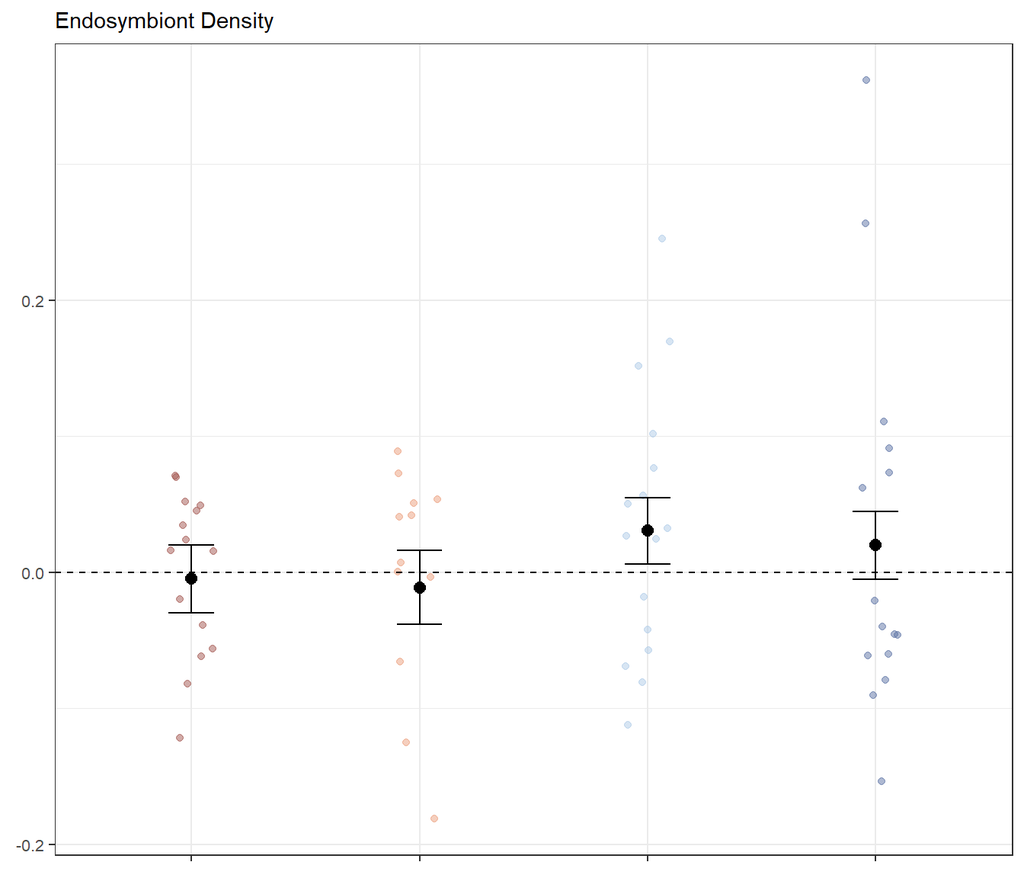

```r
ed_plot_resid <- ggplot(tidy_ed1, mapping = aes(x = Treatment, y = estimate)) +
  geom_jitter(mapping = aes(x = Treatment, y = resid, color = Treatment), size =1.5,  alpha = 0.5, width = 0.1) +
    geom_point(size = 2.5) +
  geom_errorbar(mapping = aes(ymax = high, ymin= low), width=0.2) +
  labs(y = "",x = "", title = "Endosymbiont Density") +
  theme_bw() +
  scale_color_manual(values = colors) +
  geom_hline(yintercept = 0, lty = 2) +
  theme(axis.text.y = element_text(size = 8),
        axis.text.x = element_blank(),
        legend.position = "none",
        strip.text = element_text(size = 10),
        axis.title.x = element_markdown(size = 10),
        axis.title.y = element_markdown(size = 10),
        title = element_text(size = 9))

ed_plot_resid
```

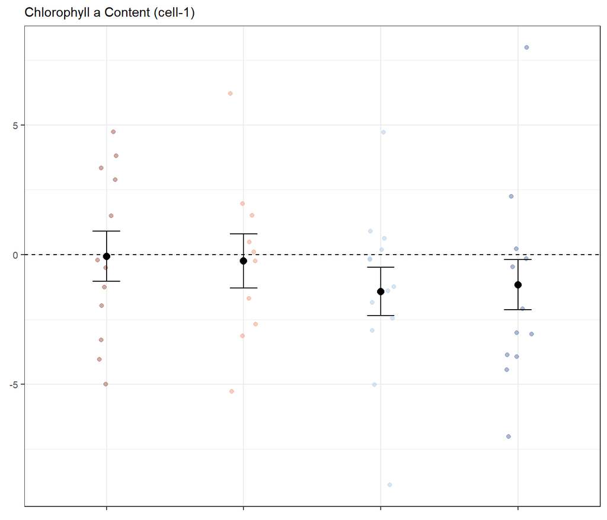

```r
cc_plot_resid <- ggplot(tidy_cc1, mapping = aes(x = Treatment, y = estimate)) +
  geom_jitter(mapping = aes(x = Treatment, y = resid, color = Treatment), size =1.5,  alpha = 0.5, width = 0.1) +
    geom_point(size = 2.5) +
  geom_errorbar(mapping = aes(ymax = high, ymin= low), width=0.2) +
  labs(y = "",x = "", title = "Chlorophyll a Content (cell-1)") +
  theme_bw() +
  scale_color_manual(values = colors) +
  geom_hline(yintercept = 0, lty = 2) +
  theme(axis.text.y = element_text(size = 8),
        axis.text.x = element_blank(),
        legend.position = "none",
        strip.text = element_text(size = 10),
        axis.title.x = element_markdown(size = 10),
        axis.title.y = element_markdown(size = 10),
        title = element_text(size = 9)) +
  geom_text(data = label.dfr, label = "", size = 10)


cc_plot_resid
```

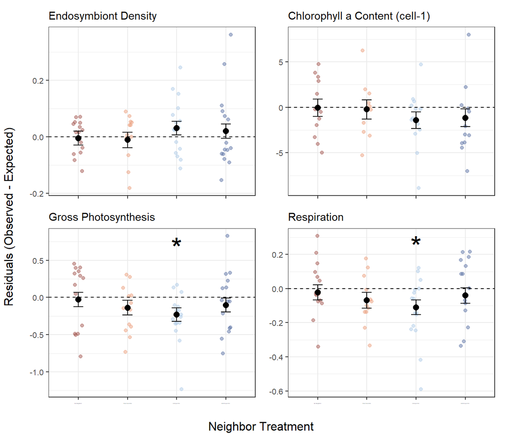

```r
resid_combined <-
  ed_plot_resid + cc_plot_resid + gp_plot_resid + r_plot_resid +
  plot_layout(guides = "collect")

result_resid <- patchwork::patchworkGrob(resid_combined)
plot_resid <- gridExtra::grid.arrange(result_resid, left = "Residuals (Observed - Expected)",
                                      bottom = "Neighbor Treatment")
```

Tables for model selection stats

```r
ed_table <- ed_nn_results_cleannames %>%
  select(Predictor, term, estimate, std.error, statistic, p.value, r.squared, adj.r.squared, AIC) %>%
  mutate(Response = "Endosymbiont Density",
         delAIC = AIC - min(AIC)) %>%
  arrange(delAIC) %>%
  select(Response, everything())


cc_table <- cc_nn_results_cleannames %>%
  select(Predictor, term, estimate, std.error, statistic, p.value, r.squared, adj.r.squared, AIC) %>%
  mutate(Response = "Chlorophyll a Content (cell-1)",
         delAIC = AIC - min(AIC)) %>%
  arrange(delAIC) %>%
  select(Response, everything())

gp_table <- gp_nn_results_cleannames %>%
  select(Predictor, term, estimate, std.error, statistic, p.value, r.squared, adj.r.squared, AIC) %>%
  mutate(Response = "Gross Photosynthesis",
         delAIC = AIC - min(AIC)) %>%
  arrange(delAIC) %>%
  select(Response, everything())

r_table <- results_r_nn_cleannames %>%
  select(Predictor, term, estimate, std.error, statistic, p.value, r.squared, adj.r.squared, AIC) %>%
  mutate(Response = "Respiration",
         delAIC = AIC - min(AIC)) %>%
  arrange(delAIC) %>%
  select(Response, everything())

table_modelselect_data <- rbind(ed_table, cc_table, gp_table, r_table) %>%
  rename(`ΔAIC` = delAIC) %>%
  arrange(Response) %>%
  mutate(round(across(is.numeric), 2)) %>%
  select(!c(std.error, statistic, r.squared, adj.r.squared)) %>%
  rename(Term = term, Estimate = estimate,`P-value` = p.value) %>%
  mutate(Term = if_else(Term == "Predictor_scaled", "Predictor Scaled", Term)) %>%
  filter(Term == "Predictor Scaled")

table_modelselect  <- table_modelselect_data %>%
  kbl() %>%
  kable_classic_2(full_width = F, html_font = "Cambria", "striped") %>%
  pack_rows(index = table(table_modelselect_data$Response))
  # column_spec(c(5, 6, 7), color = "white", background = "#a45851") %>%
  # column_spec(c(2, 3, 4), color = "white", background = "#5d74a5") %>%
  # add_header_above(c(" " = 1, "Low Range" = 3, "High Range" = 3, " " = 1))

table_modelselect
```

| Response | Predictor | Term | Estimate | P-value | AIC | ΔAIC |
| --- | --- | --- | --- | --- | --- | --- |
| **Chlorophyll a Content (cell-1)** |  |  |  |  |  |  |
| Chlorophyll a Content (cell-1) | Min Nitrite + Nitrate | Predictor Scaled | -1.75 | 0.26 | 88.29 | 0.00 |
| Chlorophyll a Content (cell-1) | Max Salinity | Predictor Scaled | 0.99 | 0.48 | 89.20 | 0.91 |
| Chlorophyll a Content (cell-1) | Mean Salinity | Predictor Scaled | 1.14 | 0.48 | 89.21 | 0.92 |
| Chlorophyll a Content (cell-1) | Min Temperature | Predictor Scaled | 0.90 | 0.50 | 89.28 | 0.99 |
| Chlorophyll a Content (cell-1) | Min Salinity | Predictor Scaled | 1.02 | 0.53 | 89.33 | 1.04 |
| Chlorophyll a Content (cell-1) | Mean Temperature | Predictor Scaled | 0.72 | 0.57 | 89.44 | 1.15 |
| Chlorophyll a Content (cell-1) | Mean Nitrite + Nitrate | Predictor Scaled | -0.83 | 0.59 | 89.47 | 1.18 |
| Chlorophyll a Content (cell-1) | Temperature Range | Predictor Scaled | -0.75 | 0.65 | 89.58 | 1.29 |
| Chlorophyll a Content (cell-1) | Mean pH | Predictor Scaled | -0.77 | 0.66 | 89.59 | 1.30 |
| Chlorophyll a Content (cell-1) | Max pH | Predictor Scaled | -0.49 | 0.74 | 89.69 | 1.40 |
| Chlorophyll a Content (cell-1) | Nitrate + Nitrate Range | Predictor Scaled | 0.49 | 0.76 | 89.71 | 1.42 |
| Chlorophyll a Content (cell-1) | Salinity Range | Predictor Scaled | -0.34 | 0.85 | 89.78 | 1.49 |
| Chlorophyll a Content (cell-1) | Min Phosphate | Predictor Scaled | 0.25 | 0.86 | 89.78 | 1.49 |
| Chlorophyll a Content (cell-1) | pH Range | Predictor Scaled | -0.32 | 0.86 | 89.79 | 1.49 |
| Chlorophyll a Content (cell-1) | Phosphate Range | Predictor Scaled | -0.25 | 0.88 | 89.79 | 1.50 |
| Chlorophyll a Content (cell-1) | Max Temperature | Predictor Scaled | 0.20 | 0.89 | 89.80 | 1.51 |
| Chlorophyll a Content (cell-1) | Max Nitrite + Nitrate | Predictor Scaled | -0.15 | 0.93 | 89.81 | 1.52 |
| Chlorophyll a Content (cell-1) | Max Phosphate | Predictor Scaled | -0.19 | 0.93 | 89.81 | 1.52 |
| Chlorophyll a Content (cell-1) | Min pH | Predictor Scaled | -0.16 | 0.94 | 89.82 | 1.53 |
| Chlorophyll a Content (cell-1) | Mean Phosphate | Predictor Scaled | 0.05 | 0.98 | 89.82 | 1.53 |
| **Endosymbiont Density** |  |  |  |  |  |  |
| Endosymbiont Density | Min Nitrite + Nitrate | Predictor Scaled | 0.04 | 0.02 | -37.09 | 0.00 |
| Endosymbiont Density | pH Range | Predictor Scaled | 0.03 | 0.19 | -33.01 | 4.09 |
| Endosymbiont Density | Mean Nitrite + Nitrate | Predictor Scaled | 0.02 | 0.19 | -33.00 | 4.09 |
| Endosymbiont Density | Min pH | Predictor Scaled | -0.04 | 0.21 | -32.85 | 4.24 |
| Endosymbiont Density | Mean Phosphate | Predictor Scaled | 0.03 | 0.25 | -32.53 | 4.56 |
| Endosymbiont Density | Temperature Range | Predictor Scaled | 0.02 | 0.43 | -31.74 | 5.36 |
| Endosymbiont Density | Min Phosphate | Predictor Scaled | 0.01 | 0.46 | -31.64 | 5.46 |
| Endosymbiont Density | Nitrate + Nitrate Range | Predictor Scaled | -0.01 | 0.52 | -31.48 | 5.62 |

[output cut: 54 more lines]

```r
# table_modelselect %>%
#   kableExtra::save_kable(file = "table_select.html", self_contained = T)
```

Tables for no neighbor models

```r
summary(control_ed_m2)
```

```
##
## Call:
## lm(formula = Final ~ min_NN_umolL, data = ED_plot_control)
##
## Residuals:
##      Min       1Q   Median       3Q      Max
## -0.12135 -0.04715  0.01631  0.04706  0.07136
##
## Coefficients:
##              Estimate Std. Error t value Pr(>|t|)
## (Intercept)  -0.02158    0.07599  -0.284   0.7809
## min_NN_umolL  0.44327    0.17331   2.558   0.0238 *
## ---
## Signif. codes:  0 '***' 0.001 '**' 0.01 '*' 0.05 '.' 0.1 ' ' 1
##
## Residual standard error: 0.06181 on 13 degrees of freedom
## Multiple R-squared:  0.3347, Adjusted R-squared:  0.2836
## F-statistic: 6.541 on 1 and 13 DF,  p-value: 0.02385
```

```r
summary(control_cc_m)
```

```
##
## Call:
## lm(formula = Final ~ min_NN_umolL, data = CC_plot_control)
##
## Residuals:
##    Min     1Q Median     3Q    Max
## -5.004 -2.295 -0.357  3.008  4.731
##
## Coefficients:
##              Estimate Std. Error t value Pr(>|t|)
## (Intercept)    24.047      6.004   4.005   0.0025 **
## min_NN_umolL  -26.699     13.185  -2.025   0.0704 .
## ---
## Signif. codes:  0 '***' 0.001 '**' 0.01 '*' 0.05 '.' 0.1 ' ' 1
##
## Residual standard error: 3.415 on 10 degrees of freedom
## Multiple R-squared:  0.2908, Adjusted R-squared:  0.2199
## F-statistic:   4.1 on 1 and 10 DF,  p-value: 0.0704
```

```r
summary(control_gp_m2)
```

```
##
## Call:
## lm(formula = Final ~ range_pH, data = GP_plot_control)
##
## Residuals:
##     Min      1Q  Median      3Q     Max
## -0.7943 -0.4312  0.1685  0.3365  0.4543
##
## Coefficients:
##             Estimate Std. Error t value Pr(>|t|)
## (Intercept)   0.4943     0.3703   1.335   0.2048
## range_pH     15.0830     7.1022   2.124   0.0535 .
## ---
## Signif. codes:  0 '***' 0.001 '**' 0.01 '*' 0.05 '.' 0.1 ' ' 1
##
## Residual standard error: 0.4335 on 13 degrees of freedom
## Multiple R-squared:  0.2576, Adjusted R-squared:  0.2005
## F-statistic:  4.51 on 1 and 13 DF,  p-value: 0.05346
```

```r
summary(control_r_m2)
```

```
##
## Call:
## lm(formula = Final ~ range_pH, data = R_plot_control)
##
## Residuals:
##      Min       1Q   Median       3Q      Max
## -0.34106 -0.07127 -0.03050  0.08274  0.30888
##
## Coefficients:
##             Estimate Std. Error t value Pr(>|t|)
## (Intercept)  0.01396    0.14018   0.100  0.92216
## range_pH     8.97014    2.68881   3.336  0.00536 **
## ---
## Signif. codes:  0 '***' 0.001 '**' 0.01 '*' 0.05 '.' 0.1 ' ' 1
##
## Residual standard error: 0.1641 on 13 degrees of freedom
## Multiple R-squared:  0.4612, Adjusted R-squared:  0.4198
## F-statistic: 11.13 on 1 and 13 DF,  p-value: 0.005362
```

```r
control_ed_summ <- tidy(control_ed_m2) %>%
  mutate(Response = "Endosymbiont Density")
control_cc_summ <- tidy(control_cc_m) %>%
  mutate(Response = "Chlorophyll a Content (cell-1)")
control_gp_summ <- tidy(control_gp_m2) %>%
  mutate(Response = "Gross Photosynthesis")
control_r_summ <- tidy(control_r_m2) %>%
  mutate(Response = "Respiration")

table_controlstats <- rbind(control_ed_summ, control_cc_summ, control_gp_summ, control_r_summ) %>%
  arrange(Response) %>%
  select(Response, everything()) %>%
  mutate(round(across(is.numeric), 2)) %>%
  rename(Term = term, Estimate = estimate,`P-value` = p.value,
         Statistic = statistic, `Standard Error` = std.error) %>%
  mutate(Term = case_when(Term == "min_NN_umolL" ~ "Minimum Nitrate + Nitrite",
                          Term == "range_pH" ~ "pH Range",
                          Term == "Initial" ~ "Initial",
                          Term == "(Intercept)" ~ "(Intercept)"),
         `P-value` = round(`P-value`, 3),
         `P-value` = if_else(`P-value` < 0.0001, 0.0001, `P-value`),
         sig = case_when(`P-value` > 0.05 ~ "",
                         `P-value` <= 0.05 & `P-value` > 0.01 ~ "*",
                         `P-value` <= 0.01 & `P-value` > 0.001 ~ "**",
                         `P-value` <= 0.001 ~ "***"),
         `P-value` = as.character(`P-value`),
         `P-value` = if_else(`P-value` == "0.0001", "< 0.0001", `P-value`))

table_modelcontrol <- table_controlstats %>%
  kbl(col.names = c("Response", "Term", "Estimate", "Standard Error", "Statistic", "P-value", "")) %>%
  kable_classic_2(full_width = F, html_font = "Cambria", "striped") %>%
  pack_rows(index = table(table_controlstats$Response))
  # column_spec(c(5, 6, 7), color = "white", background = "#a45851") %>%
  # column_spec(c(2, 3, 4), color = "white", background = "#5d74a5") %>%
  # add_header_above(c(" " = 1, "Low Range" = 3, "High Range" = 3, " " = 1))

table_modelcontrol
```

Response

Term

Estimate

Standard Error

Statistic

P-value

**Chlorophyll a Content (cell-1)**

Chlorophyll a Content (cell-1)

(Intercept)

24.05

6.00

4.01

1e-04

***

Chlorophyll a Content (cell-1)

Minimum Nitrate + Nitrite

-26.70

13.19

-2.02

0.07

**Endosymbiont Density**

Endosymbiont Density

(Intercept)

-0.02

0.08

-0.28

0.78

Endosymbiont Density

Minimum Nitrate + Nitrite

0.44

0.17

2.56

0.02

**Gross Photosynthesis**

Gross Photosynthesis

(Intercept)

0.49

0.37

1.33

0.2

Gross Photosynthesis

pH Range

15.08

7.10

2.12

0.05

**Respiration**

Respiration

(Intercept)

0.01

0.14

0.10

0.92

Respiration

pH Range

8.97

2.69

3.34

0.01

```r
# table_modelcontrol %>%
#   kableExtra::save_kable(file = "table1.html", self_contained = T)
```

table for comp models

```r
tidy(comp_ed_m_table)
```

```
## # A tibble: 6 × 8
##   effect   group    term                  estimate std.e…¹ stati…²    df p.value
##   <chr>    <chr>    <chr>                    <dbl>   <dbl>   <dbl> <dbl>   <dbl>
## 1 fixed    <NA>     (Intercept)           -0.00481  0.0250  -0.192  45.5   0.848
## 2 fixed    <NA>     TreatmentDead_skelet… -0.00626  0.0298  -0.210  38.0   0.834
## 3 fixed    <NA>     TreatmentConspecific   0.0353   0.0283   1.25   41.4   0.220
## 4 fixed    <NA>     TreatmentHeterospeci…  0.0248   0.0283   0.876  39.2   0.386
## 5 ran_pars CowTagID sd__(Intercept)        0.0642  NA       NA      NA    NA
## 6 ran_pars Residual sd__Observation        0.0757  NA       NA      NA    NA
## # … with abbreviated variable names ¹std.error, ²statistic
```

```r
comp_ed_summ <- tidy(comp_ed_m_table) %>% mutate(Response = "Endosymbiont Density") %>%
  mutate(across(term, factor, levels = c("(Intercept)", "TreatmentDead_skeletal",
                                         "TreatmentConspecific", "TreatmentHeterospecific"),
                labels = c("(Intercept)", "Dead Skeletal", "Conspecific", "Heterospecific")))
comp_cc_summ <- tidy(comp_cc_m_table) %>% mutate(Response = "Chlorophyll a Content (cell-1)") %>%
  mutate(across(term, factor, levels = c("(Intercept)", "TreatmentDead_skeletal",
                                         "TreatmentConspecific", "TreatmentHeterospecific"),
                labels = c("(Intercept)", "Dead Skeletal", "Conspecific", "Heterospecific")))
comp_gp_summ <- tidy(comp_gp_m_table) %>% mutate(Response = "Gross Photosynthesis") %>%
  mutate(across(term, factor, levels = c("(Intercept)", "TreatmentDead_skeletal",
                                         "TreatmentConspecific", "TreatmentHeterospecific"),
                labels = c("(Intercept)", "Dead Skeletal", "Conspecific", "Heterospecific")))
comp_r_summ <- tidy(comp_r_m_table) %>% mutate(Response = "Respiration") %>%
  mutate(across(term, factor, levels = c("(Intercept)", "TreatmentDead_skeletal",
                                         "TreatmentConspecific", "TreatmentHeterospecific"),
                labels = c("(Intercept)", "Dead Skeletal", "Conspecific", "Heterospecific")))

# fixed first
table_compstats <- rbind(comp_ed_summ, comp_cc_summ, comp_gp_summ, comp_r_summ) %>%
  filter(effect == "fixed") %>%
  select(!c(effect, group)) %>%
  arrange(Response) %>%
  select(Response, everything()) %>%
  mutate(round(across(is.numeric), 2)) %>%
  rename(Term = term, Estimate = estimate,`P-value` = p.value,
         Statistic = statistic, `Standard Error` = std.error) %>%
  mutate(`P-value` = round(`P-value`, 3),
         `P-value` = if_else(`P-value` < 0.0001, 0.0001, `P-value`),
         sig = case_when(`P-value` > 0.05 ~ "",
                         `P-value` <= 0.05 & `P-value` > 0.01 ~ "*",
                         `P-value` <= 0.01 & `P-value` > 0.001 ~ "**",
                         `P-value` <= 0.001 ~ "***"),
         `P-value` = as.character(`P-value`),
         `P-value` = if_else(`P-value` == "0.0001", "< 0.0001", `P-value`))

table_modelcomp <- table_compstats %>%
  kbl(col.names = c("Response", "Term", "Estimate", "Standard Error", "Statistic", "df", "P-value", "")) %>%
  kable_classic_2(full_width = F, html_font = "Cambria", "striped") %>%
  pack_rows(index = table(table_compstats$Response))
  # column_spec(c(5, 6, 7), color = "white", background = "#a45851") %>%
  # column_spec(c(2, 3, 4), color = "white", background = "#5d74a5") %>%
  # add_header_above(c(" " = 1, "Low Range" = 3, "High Range" = 3, " " = 1))

table_modelcomp
```

Response

Term

Estimate

Standard Error

Statistic

df

P-value

**Chlorophyll a Content (cell-1)**

Chlorophyll a Content (cell-1)

(Intercept)

-0.07

0.96

-0.07

40.90

0.95

Chlorophyll a Content (cell-1)

Dead Skeletal

-0.17

1.24

-0.14

30.13

0.89

Chlorophyll a Content (cell-1)

Conspecific

-1.35

1.18

-1.15

32.77

0.26

Chlorophyll a Content (cell-1)

Heterospecific

-1.10

1.20

-0.92

31.62

0.37

**Endosymbiont Density**

Endosymbiont Density

(Intercept)

0.00

0.02

-0.19

45.50

0.85

Endosymbiont Density

Dead Skeletal

-0.01

0.03

-0.21

38.01

0.83

Endosymbiont Density

Conspecific

0.04

0.03

1.25

41.35

0.22

Endosymbiont Density

Heterospecific

0.02

0.03

0.88

39.17

0.39

**Gross Photosynthesis**

Gross Photosynthesis

(Intercept)

-0.03

0.09

-0.30

37.27

0.77

Gross Photosynthesis

Dead Skeletal

-0.11

0.09

-1.16

35.14

0.25

Gross Photosynthesis

Conspecific

-0.20

0.09

-2.17

38.55

0.04

Gross Photosynthesis

Heterospecific

-0.07

0.09

-0.79

36.52

0.43

**Respiration**

Respiration

(Intercept)

-0.02

0.04

-0.50

31.59

0.62

Respiration

Dead Skeletal

-0.05

0.04

-1.13

33.07

0.27

Respiration

Conspecific

-0.09

0.04

-2.14

36.11

0.04

Respiration

Heterospecific

-0.02

0.04

-0.45

34.28